# Accident Forecasting

- Show All Code
- Hide All Code
- View Source

## Load packages

**Hide code**

```r
library(tidyverse)
library(sf)
library(jsonlite)
```

## Import data

**Hide code**

```r
# Specify the path to the geojson file
file_path <- "sankt-peterburg.geojson"

# Load the geojson file using sf
geojson_data <- st_read(file_path)
```

```
replacing null geometries with empty geometries
Simple feature collection with 54550 features and 20 fields (with 1194 geometries empty)
Geometry type: POINT
Dimension:     XY
Bounding box:  xmin: 0.008056 ymin: 0.0158 xmax: 111 ymax: 69.86667
Geodetic CRS:  WGS 84
```

**Hide code**

```r
# If you want a flattened dataframe
flattened_data <- as.data.frame(geojson_data)
```

## Prepare clean data

**Hide code**

```r
data<-flattened_data%>%
  select(id,point,datetime,severity, region)%>%
  mutate(latitude = str_extract(point, '"lat":\\s*([0-9\\.\\-]+)') %>%
      str_remove('"lat":\\s*') %>%
      as.numeric(),

    longitude = str_extract(point, '"long":\\s*([0-9\\.\\-]+)') %>%
      str_remove('"long":\\s*') %>%
      as.numeric())%>%
  select(-point)

data$severity[data$severity=="Легкий"]<-"Light"
data$severity[data$severity=="С погибшими"]<-"Fatal"
data$severity[data$severity=="Тяжёлый"]<-"Severe"

data$severity_binary<-"Light"
data$severity_binary[data$severity%in%c("Severe","Fatal")]<-"Severe/Fatal"
```

## Remove outliers

**Hide code**

```r
summary(data$latitude)
```

```
   Min. 1st Qu.  Median    Mean 3rd Qu.    Max.    NA's
 0.0158 59.8445 59.9206 59.4432 59.9881 69.8667    1194
```

**Hide code**

```r
summary(data$longitude)
```

```
    Min.  1st Qu.   Median     Mean  3rd Qu.     Max.     NA's
  0.0081  30.2463  30.3312  30.2986  30.4075 111.0000     1194
```

**Hide code**

```r
data<-data%>%filter(longitude>10)
summary(data$longitude)
```

```
   Min. 1st Qu.  Median    Mean 3rd Qu.    Max.
  10.34   30.25   30.33   30.44   30.41  111.00
```

## Transliterate names of districts from Russian to English

**Hide code**

```r
library(stringi)
data$region<-gsub("rajon","district",stri_trans_general(data$region, "ru-Latn"))
```

## Keep only accidents from 2022 to 2024 with valid latitude and longitude

**Hide code**

```r
data<-data%>%
  filter(year(datetime)>=2022,
         !is.na(latitude))
```

## Save data to xlsx file

**Hide code**

```r
library(rio)
export(data,"data.xlsx")
```

**Hide code**

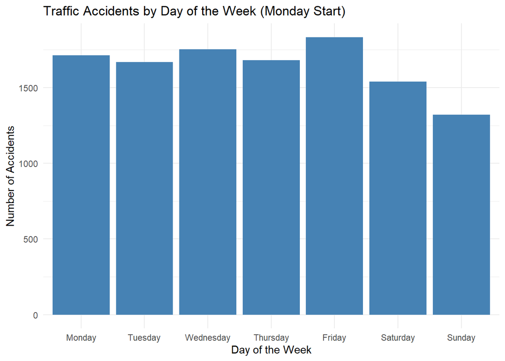

```r
# Load necessary libraries
library(dplyr)
library(lubridate)
library(ggplot2)

# Convert datetime to appropriate formats if necessary
data <- data %>%
  mutate(day_of_week = wday(datetime, label = TRUE, abbr = FALSE, week_start = 1), # Week starts on Monday
         hour_of_day = hour(datetime))                                             # Extract hour

# Traffic accidents by day of the week
accidents_by_day <- data %>%
  group_by(day_of_week) %>%
  summarise(count = n())

# Plot accidents by day of the week
ggplot(accidents_by_day, aes(x = day_of_week, y = count)) +
  geom_bar(stat = "identity", fill = "steelblue") +
  labs(title = "Traffic Accidents by Day of the Week (Monday Start)",
       x = "Day of the Week", y = "Number of Accidents") +
  theme_minimal()
```

## Analysis of determinants of accidents in each administrative district of Saint-Petersburg

### Dataset

**Hide code**

```r
library(dplyr)
library(lubridate)
library(tidyr)
# keep only severe/fatal accidents
#data<-data%>%
  #filter(severity_binary=="Severe/Fatal")

# 1. Extract hour, day of the week, and month
data <- data %>%
  mutate(
    date = as.Date(datetime),
    hour = hour(datetime),
    day_of_week = wday(datetime, label = TRUE),
    month = month(datetime, label = TRUE)
  )

# 2. Create a complete grid of dates, hours, and regions
complete_grid <- expand_grid(
  date = seq(min(data$date), max(data$date), by = "day"),
  hour = 0:23,
  region = unique(data$region)
)

# 3. Aggregate accident counts per district
accidents_by_district <- data %>%
  group_by(date, hour, region) %>%
  summarise(accident_count = n(), .groups = 'drop')

# 4. Merge with the complete grid to include all hours, even those with no accidents
accidents_complete <- complete_grid %>%
  left_join(accidents_by_district, by = c("date", "hour", "region")) %>%
  mutate(accident_count = replace_na(accident_count, 0))

# 5. Pivot to wide format with one column per region
accidents_wide <- accidents_complete %>%
  pivot_wider(names_from = region, values_from = accident_count, values_fill = 0)
```

### Append weather data

Weather data was obtained through free weather API using the following API URL: https://archive-api.open-meteo.com/v1/archive?latitude=59.9386&longitude=30.3141&start_date=2022-01-01&end_date=2024-12-01&hourly=temperature_2m,relative_humidity_2m,dew_point_2m,apparent_temperature,precipitation,rain,snowfall,snow_depth,weather_code,pressure_msl,surface_pressure,cloud_cover,cloud_cover_low,cloud_cover_mid,cloud_cover_high,et0_fao_evapotranspiration,vapour_pressure_deficit,wind_speed_10m,wind_speed_100m,wind_direction_10m,wind_direction_100m,wind_gusts_10m

The dataset was saved as weather.xlsx, imported to R and appended to the hourly accidents dataset.

**Hide code**

```r
weather<-import("weather.xlsx")%>%
  mutate(date=as.Date(time),
         hour=hour(time))

accidents_wide<-accidents_wide%>%
  left_join(weather)%>%
  janitor::clean_names()
```

### Regression tree (outcome: each district’s accident count in each hour)

The analysis using regression trees has shown that analysis of accident counts for each city district has little predictive power and reveals only trivial rules like “the intensity of accidents is lower before 8am than after”, and even these rules were inferred only for Nevskij and Vyborgskij districts. Part of the reason is that district division of Saint-Petersburg is rather arbitrary and does not account for accident hotspots. That is why it was decided to apply time series analysis for each cluster of hotspots rather than by any other arbitary division of the city.

**Hide code**

```r
library(dplyr)
library(rpart)

# Prepare the dataset for tree-based modeling
accidents_wide <- accidents_wide %>%
  mutate(
    day_of_week = as.factor(weekdays(date)), # Categorical day of week
    month = as.factor(format(date, "%m"))    # Categorical month
  )

# Add lags for all variables ending with "_district"
accidents_wide <- accidents_wide %>%
  group_by(date) %>%
  mutate(across(
    ends_with("_district"),
    .fns = list(
      lag_1 = ~ lag(.x, 1),
      lag_2 = ~ lag(.x, 2),
      lag_3 = ~ lag(.x, 3),
      lag_4 = ~ lag(.x, 4),
      lag_24 = ~ lag(.x, 24),
      lag_24_7 = ~ lag(.x, 24 * 7)
    ),
    .names = "{.col}_{.fn}"
  )) %>%
  ungroup()

# Get all district variables
district_vars <- colnames(accidents_wide) %>%
  .[grepl("_district$", .)]

# Build a decision tree for each district variable
tree_list <- list() # To store trees for each district variable

for (district_var in district_vars) {
  # Prepare data for the model, excluding current district and unnecessary columns
  data_for_tree <- accidents_wide %>%
    select(
      -ends_with("_district"),
      -date,
      -time,
      all_of(district_var)
    ) %>%
    rename(target = all_of(district_var)) # Rename target variable for modeling

  # Build the decision tree
  tree <- rpart(
    target ~ .,
    data = data_for_tree,
    method = "anova" # Change to "class" if classification is intended
  )

  # Store the tree with the district variable name
  tree_list[[district_var]] <- tree
}
```

### Print regression tree rules

**Hide code**

```r
library(rpart.plot)

# Print rules for each tree in the list
for (district_var in names(tree_list)) {
  cat("\nRules for:", district_var, "\n")
  print(rpart.rules(tree_list[[district_var]], style = "tallw", cover = TRUE))
  cat("\n--------------------\n")
}
```

```
Rules for: central_nyj_district
target is 0.034 with cover 100% null model


--------------------

Rules for: frunzenskij_district
target is 0.024 with cover 100% null model


--------------------

Rules for: puskinskij_district
target is 0.02 with cover 100% null model


--------------------

Rules for: petrodvorcovyj_district
target is 0.01 with cover 100% null model


--------------------

Rules for: petrogradskij_district
target is 0.015 with cover 100% null model


--------------------

Rules for: nevskij_district
target is 0.016 with cover 33% when
                hour < 8

target is 0.068 with cover 67% when
                hour >= 8

--------------------

Rules for: moskovskij_district
```

[output cut: 58 more lines]

```
                hour >= 8

--------------------

Rules for: vasileostrovskij_district
target is 0.017 with cover 100% null model


--------------------

Rules for: admiraltejskij_district
target is 0.02 with cover 100% null model


--------------------
```

## Analysis of determinants of accidents in each DBSCAN cluster of Saint-Petersburg

### Dataset

**Hide code**

```r
library(dplyr)
library(lubridate)
library(tidyr)
library(dbscan)
library(leaflet)

# Step 1: Extract hour, day of the week, and month
data <- data %>%
  mutate(
    date = as.Date(datetime),
    hour = hour(datetime),
    day_of_week = wday(datetime, label = TRUE),
    month = month(datetime, label = TRUE)
  )

# Step 2: Prepare data for clustering
# Select relevant features for clustering (e.g., latitude and longitude)
clustering_data <- data %>%
  select(latitude, longitude) %>%
  distinct() # Remove duplicates to avoid redundancy in clustering

# Step 3: Apply DBSCAN for clustering
# Adjust `eps` and `minPts` based on your dataset
dbscan_result <- dbscan::dbscan(
  clustering_data,
  eps = 0.01, # Adjust radius for clustering based on your data scale
  minPts = 100  # Minimum points to form a cluster
)

# Add the cluster labels back to the dataset
clustering_data <- clustering_data %>%
  mutate(cluster = dbscan_result$cluster)

# Merge cluster labels back to the main data
data <- data %>%
  left_join(clustering_data, by = c("latitude", "longitude"))

# Step 4: Create a complete grid of dates, hours, and cluster numbers
complete_grid <- expand_grid(
  date = seq(min(data$date), max(data$date), by = "day"),
  hour = 0:23,
  cluster = unique(data$cluster)
)

# Step 5: Aggregate accident counts per cluster
accidents_by_cluster <- data %>%
  group_by(date, hour, cluster) %>%
  summarise(accident_count = n(), .groups = 'drop')

# Step 6: Merge with the complete grid to include all hours, even those with no accidents
accidents_complete <- complete_grid %>%
  left_join(accidents_by_cluster, by = c("date", "hour", "cluster")) %>%
  mutate(accident_count = replace_na(accident_count, 0))

# Step 7: Pivot to wide format with prefixed column names
accidents_wide <- accidents_complete %>%
  pivot_wider(
    names_from = cluster,
    names_prefix = "count_cluster_",
    values_from = accident_count,
    values_fill = 0
  )

# Step 8: Visualize clusters on a Leaflet map
# Filter noise points (optional: cluster 0)
clustering_data_filtered <- clustering_data %>%
  filter(cluster > 0)

# Create a color palette for clusters
palette <- colorFactor(
  palette = "Set1", # Choose a color palette
  domain = clustering_data_filtered$cluster
)

# Generate the Leaflet map
leaflet_map <- leaflet(clustering_data_filtered) %>%
  addTiles() %>%  # Add base map tiles
  addCircleMarkers(
    ~longitude,
    ~latitude,
    color = ~palette(cluster),
    radius = 5,
    stroke = FALSE,
    fillOpacity = 0.8,
    label = ~paste("Cluster:", cluster)
  )

# Print the map
leaflet_map
```

[interactive chart not shown]

### Append weather data

Weather data was obtained through free weather API using the following API URL: https://archive-api.open-meteo.com/v1/archive?latitude=59.9386&longitude=30.3141&start_date=2022-01-01&end_date=2024-12-01&hourly=temperature_2m,relative_humidity_2m,dew_point_2m,apparent_temperature,precipitation,rain,snowfall,snow_depth,weather_code,pressure_msl,surface_pressure,cloud_cover,cloud_cover_low,cloud_cover_mid,cloud_cover_high,et0_fao_evapotranspiration,vapour_pressure_deficit,wind_speed_10m,wind_speed_100m,wind_direction_10m,wind_direction_100m,wind_gusts_10m

The dataset was saved as weather.xlsx, imported to R and appended to the hourly accidents dataset.

**Hide code**

```r
weather<-import("weather.xlsx")%>%
  mutate(date=as.Date(time),
         hour=hour(time))

accidents_wide<-accidents_wide%>%
  left_join(weather)%>%
  janitor::clean_names()
```

### Regression tree (oucome: each DBSCAN cluster’s accident count)

**Hide code**

```r
library(dplyr)
library(rpart)

# Prepare the dataset for tree-based modeling
accidents_wide <- accidents_wide %>%
  mutate(
    day_of_week = as.factor(weekdays(date)), # Categorical day of week
    month = as.factor(format(date, "%m")),  # Categorical month
    hour = as.factor(hour)                  # Categorical hour
  )

# Add lags for all variables starting with "count_cluster_"
accidents_wide <- accidents_wide %>%
  group_by(date) %>%
  mutate(across(
    starts_with("count_cluster_"),
    .fns = list(
      lag_1 = ~ lag(.x, 1),
      lag_2 = ~ lag(.x, 2),
      lag_3 = ~ lag(.x, 3),
      lag_4 = ~ lag(.x, 4),
      lag_24 = ~ lag(.x, 24),
      lag_24_7 = ~ lag(.x, 24 * 7)
    ),
    .names = "{.col}_{.fn}"
  )) %>%
  ungroup()

# Get all original cluster variables (outcomes)
outcome_vars <- colnames(accidents_wide) %>%
  .[grepl("^count_cluster_\\d+$", .)] # Only non-lagged variables

# Get all lagged variables (predictors)
predictor_vars <- colnames(accidents_wide) %>%
  .[grepl("^count_cluster_\\d+_lag_", .)]

# Include additional predictors (month, day_of_week, hour)
additional_predictors <- c("month", "day_of_week", "hour")

# Build a decision tree for each outcome variable
tree_list <- list() # To store trees for each outcome variable

for (outcome_var in outcome_vars) {
  # Prepare data for the model
  data_for_tree <- accidents_wide %>%
    select(
      all_of(predictor_vars),       # Include lagged variables as predictors
      all_of(additional_predictors),# Include additional predictors
      all_of(outcome_var)           # Include only the current outcome variable
    ) %>%
    rename(target = all_of(outcome_var)) # Rename target variable for modeling

  # Build the decision tree
  tree <- rpart(
    target ~ .,  # Use all remaining variables as predictors
    data = data_for_tree,
    method = "anova" # Change to "class" if classification is intended
  )

  # Store the tree with the outcome variable name
  tree_list[[outcome_var]] <- tree
}
```

### Print regression tree rules

**Hide code**

```r
library(rpart.plot)

# Print rules for each tree in the list
for (district_var in names(tree_list)) {
  cat("\nRules for:", district_var, "\n")
  print(rpart.rules(tree_list[[district_var]], style = "tallw", cover = TRUE))
  cat("\n--------------------\n")
}
```

```
Rules for: count_cluster_1
target is 0.052 with cover 100% null model


--------------------

Rules for: count_cluster_0
target is 0.14 with cover 38% when
               hour is 0 or 1 or 2 or 3 or 4 or 5 or 6 or 7 or 23

target is 0.53 with cover 62% when
               hour is 8 or 9 or 10 or 11 or 12 or 13 or 14 or 15 or 16 or 17 or 18 or 19 or 20 or 21 or 22

--------------------

Rules for: count_cluster_2
target is 0.0062 with cover 100% null model


--------------------

Rules for: count_cluster_3
target is 0.0098 with cover 100% null model


--------------------

Rules for: count_cluster_4
target is 0.0065 with cover 100% null model


--------------------

Rules for: count_cluster_5
target is 0.0054 with cover 100% null model


--------------------

Rules for: count_cluster_6
target is 0.0041 with cover 100% null model


--------------------

Rules for: count_cluster_7
target is 0.0046 with cover 100% null model


--------------------

Rules for: count_cluster_8
target is 0.0081 with cover 100% null model


--------------------
```

Extremely low predictability of location and time of accidents was revealed suggesting that it is important to focus on hotspots revealed using the DBSCAN algorithm that create traffic bottlenecks and pose threat to human lives.

## Classification modeling of accident occurence

In this version of the analysis we predict not the number of accidents, but the probability of its occurence.

**Hide code**

```r
library(dplyr)
library(rpart)

# Prepare the dataset for tree-based modeling
accidents_wide <- accidents_wide %>%
  mutate(
    day_of_week = as.factor(weekdays(date)), # Categorical day of week
    month = as.factor(format(date, "%m")),  # Categorical month
    hour = as.factor(hour)                  # Categorical hour
  )

# Add lags for all variables starting with "count_cluster_"
accidents_wide <- accidents_wide %>%
  group_by(date) %>%
  mutate(across(
    starts_with("count_cluster_"),
    .fns = list(
      lag_1 = ~ lag(.x, 1),
      lag_2 = ~ lag(.x, 2),
      lag_3 = ~ lag(.x, 3),
      lag_4 = ~ lag(.x, 4),
      lag_24 = ~ lag(.x, 24),
      lag_24_7 = ~ lag(.x, 24 * 7)
    ),
    .names = "{.col}_{.fn}"
  )) %>%
  ungroup()

# Convert outcome variables to binary (classification)
# Binary outcome: 1 if accident count > 0, otherwise 0
accidents_wide <- accidents_wide %>%
  mutate(across(
    starts_with("count_cluster_"),
    ~ as.factor(ifelse(.x > 0, 1, 0)),
    .names = "{.col}_binary"
  ))

# Get all binary outcome variables
outcome_vars <- colnames(accidents_wide) %>%
  .[grepl("^count_cluster_\\d+_binary$", .)] # Only binary variables

# Get all lagged variables (predictors)
predictor_vars <- colnames(accidents_wide) %>%
  .[grepl("^count_cluster_\\d+_lag_", .)]

# Include additional predictors (month, day_of_week, hour)
additional_predictors <- c("month", "day_of_week", "hour")

# Build a classification tree for each binary outcome variable
tree_list <- list() # To store trees for each binary outcome variable

for (outcome_var in outcome_vars) {
  # Prepare data for the model
  data_for_tree <- accidents_wide %>%
    select(
      all_of(predictor_vars),       # Include lagged variables as predictors
      all_of(additional_predictors),# Include additional predictors
      all_of(outcome_var)           # Include only the current binary outcome variable
    ) %>%
    rename(target = all_of(outcome_var)) # Rename target variable for modeling

  # Build the classification tree
  tree <- rpart(
    target ~ .,  # Use all remaining variables as predictors
    data = data_for_tree,
    method = "class" # Classification model
  )

  # Store the tree with the binary outcome variable name
  tree_list[[outcome_var]] <- tree
}
```

### Print classification tree rules

**Hide code**

```r
library(rpart.plot)

# Print rules for each tree in the list
for (district_var in names(tree_list)) {
  cat("\nRules for:", district_var, "\n")
  print(rpart.rules(tree_list[[district_var]], style = "tallw", cover = TRUE))
  cat("\n--------------------\n")
}
```

```
Rules for: count_cluster_1_binary
target is 0.05 with cover 100% null model


--------------------

Rules for: count_cluster_0_binary
target is 0.30 with cover 100% null model


--------------------

Rules for: count_cluster_2_binary
target is 0.01 with cover 100% null model


--------------------

Rules for: count_cluster_3_binary
target is 0.01 with cover 100% null model


--------------------

Rules for: count_cluster_4_binary
target is 0.01 with cover 100% null model


--------------------

Rules for: count_cluster_5_binary
target is 0.01 with cover 100% null model


--------------------

Rules for: count_cluster_6_binary
target is 0.00 with cover 100% null model


--------------------

Rules for: count_cluster_7_binary
target is 0.00 with cover 100% null model


--------------------

Rules for: count_cluster_8_binary
target is 0.01 with cover 100% null model


--------------------
```

The conclusion remained the same no matter which popular tree-based algorithm we used (Random Forest, XGboost, CatBoost). This might be due to the sparse nature of the data when each hotspot is comprised of only several events over the 2.5 year period. Further refinement of the DBSCAN clustering solution may help solve this issue.